# PML Final Project

Ryan Summe

2024-04-19

```r
library(tidyverse)
library(tidymodels)
library(corrr)
```

### Import Data

Import training and test data sets. Automatically infer data types.

```r
# Add #DIV/0! as an NA value since it is in the CSV
training <- read_csv('Data/pml-training.csv', show_col_types=FALSE, na=c('','NA','#DIV/0!'))
test <- read_csv('Data/pml-testing.csv', show_col_types=FALSE)
```

### Data Review

Training set is `19622` rows by `160` columns. There are many numeric variables related to the gyroscopes and accelerometers, which is very difficult to read directly. There are usernames, timestamps, and several factor-looking variables like `new_window`, `num_window`, and `classe`. `classe` is the variable we are trying to predict.

There are 6 users, and 20 unique timestamps. I am converting the `cvtd_timestamp` to a date format so that I can test it in my feature tuning. Also remove the first column as it is just row numbers. There are raw numerical timestamp columns (`part_1` and `part_2`) that can likely be used in the model instead of dealing with the date time conversion.

There are 5 different levels of `classe`.

```r
training |> count(user_name)
```

```
## # A tibble: 6 × 2
##   user_name     n
##   <chr>     <int>
## 1 adelmo     3892
## 2 carlitos   3112
## 3 charles    3536
## 4 eurico     3070
## 5 jeremy     3402
## 6 pedro      2610
```

```r
training |> count(cvtd_timestamp)
```

```
## # A tibble: 20 × 2
##    cvtd_timestamp       n
##    <chr>            <int>
##  1 02/12/2011 13:32   177
##  2 02/12/2011 13:33  1321
##  3 02/12/2011 13:34  1375
##  4 02/12/2011 13:35  1019
##  5 02/12/2011 14:56   235
##  6 02/12/2011 14:57  1380
##  7 02/12/2011 14:58  1364
##  8 02/12/2011 14:59   557
##  9 05/12/2011 11:23   190
## 10 05/12/2011 11:24  1497
## 11 05/12/2011 11:25  1425
## 12 05/12/2011 14:22   267
## 13 05/12/2011 14:23  1370
## 14 05/12/2011 14:24   973
## 15 28/11/2011 14:13   833
## 16 28/11/2011 14:14  1498
## 17 28/11/2011 14:15   739
## 18 30/11/2011 17:10   869
## 19 30/11/2011 17:11  1440
## 20 30/11/2011 17:12  1093
```

```r
training |> count(classe)
```

```
## # A tibble: 5 × 2
##   classe     n
##   <chr>  <int>
## 1 A       5580
## 2 B       3797
## 3 C       3422
## 4 D       3216
## 5 E       3607
```

```r
# Inspect non-numeric variables to see if there are importing errors
# Some columns are all NA which should be dropped
training |> select(-where(is.numeric)) |> summary()
```

```
##   user_name         cvtd_timestamp      new_window        kurtosis_yaw_belt
##  Length:19622       Length:19622       Length:19622       Mode:logical
##  Class :character   Class :character   Class :character   NA's:19622
##  Mode  :character   Mode  :character   Mode  :character
##  skewness_yaw_belt kurtosis_yaw_dumbbell skewness_yaw_dumbbell
##  Mode:logical      Mode:logical          Mode:logical
##  NA's:19622        NA's:19622            NA's:19622
##
##  kurtosis_yaw_forearm skewness_yaw_forearm    classe
##  Mode:logical         Mode:logical         Length:19622
##  NA's:19622           NA's:19622           Class :character
##                                            Mode  :character
```

```r
# All logical columns are NA
training <- training |> select(-where(is_logical))

training <- training |> mutate(cvtd_timestamp=dmy_hm(cvtd_timestamp)) |> select(-1)
test <- test |> mutate(cvtd_timestamp=dmy_hm(cvtd_timestamp)) |> select(-1)
# There are many variables that look to be calculated off of other columns (min, max, avg) but
# they are frequently NA. I'm removing these so that our training data has more complete
# cases for model training.
naColumnNames <- training |> slice(1) |> select(where(~all(is.na(.x)))) |> names()
training <- training |> select(-all_of(naColumnNames)) |> na.omit()
```

### Check Correlations

Create correlation matrix to get an idea of how variables are correlated. Select numeric columns, correlate, drop reciprocal correlations (X:Y vs Y:X), and turn into a long data frame sorted by r.

```r
training |>
  select(where(is.numeric)) |>
  correlate() |> shave() |>
  stretch(na.rm=TRUE) |> arrange(-r)
```

```
## Correlation computed with
## • Method: 'pearson'
## • Missing treated using: 'pairwise.complete.obs'
```

```
## # A tibble: 1,485 × 3
##    x                y                    r
##    <chr>            <chr>            <dbl>
##  1 roll_belt        total_accel_belt 0.981
##  2 gyros_dumbbell_z gyros_forearm_z  0.933
##  3 total_accel_belt accel_belt_y     0.928
##  4 roll_belt        accel_belt_y     0.925
##  5 accel_belt_x     magnet_belt_x    0.892
##  6 yaw_dumbbell     accel_dumbbell_z 0.849
##  7 gyros_forearm_y  gyros_forearm_z  0.846
##  8 roll_belt        yaw_belt         0.815
##  9 magnet_arm_y     magnet_arm_z     0.814
## 10 accel_arm_x      magnet_arm_x     0.814
## # ℹ 1,475 more rows
```

### Create TidyModels Recipe

Use `tidymodels` to design a recipe for ingesting training data and applying several steps of feature engineering. This includes identifying ID columns, creating dummy variables for nominal variables, removing zero variance predictors, and centering and scaling predictors.

Once feature engineering is done, apply Principal Component Analysis to reduce dimensionality. Visualize our principal components.

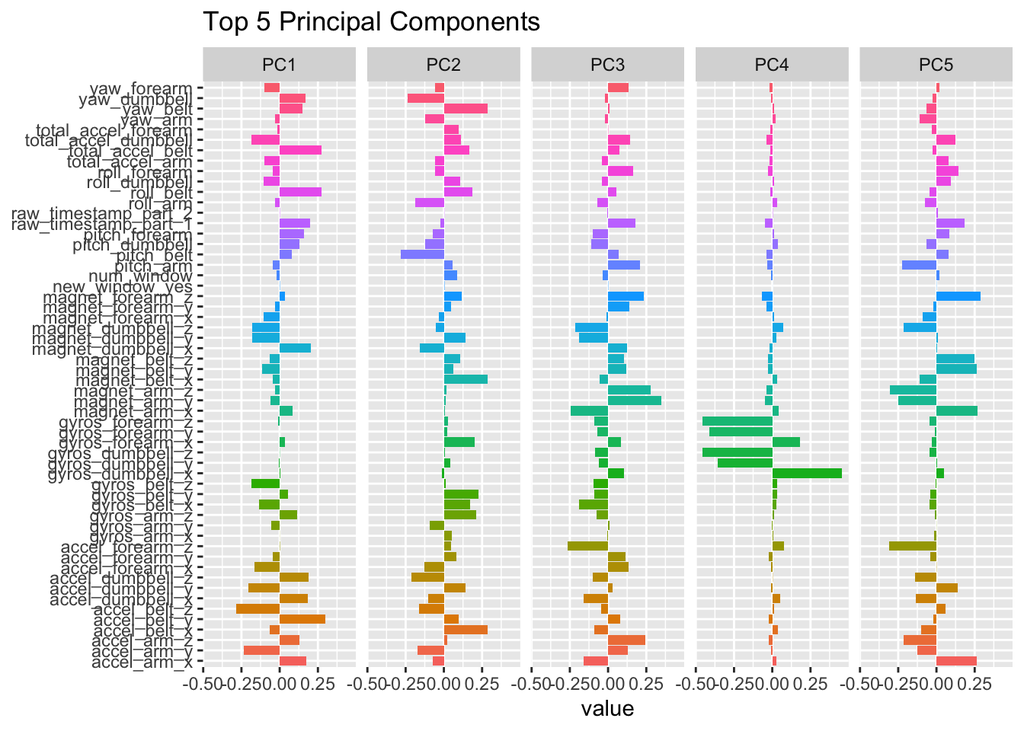

```r
rec <- recipe(classe ~ ., data=training) |>
  # Set username and timestamp as IDs. There are numerical timestamps
  update_role(user_name, cvtd_timestamp, new_role='ID') |>
  # Create dummy variable for new_window
  step_dummy(new_window) |>
  # Remove variables with zero variance
  step_zv(all_predictors()) |>
  # Normalize (center and scale) predictors
  step_normalize(all_predictors()) |>
  step_pca(all_predictors())

rec_noPCA <- recipe(classe ~ ., data=training) |>
  update_role(user_name, cvtd_timestamp, new_role='ID') |>
  step_dummy(new_window) |>
  step_zv(all_predictors()) |>
  step_normalize(all_predictors())

# Visualize First 5 Components
prep(rec) |> tidy(4) |>
  filter(component %in% paste0('PC', 1:5)) |>
  mutate(component=fct_inorder(component)) |>
  ggplot(aes(value, terms, fill=terms)) + geom_col(show.legend=FALSE) +
  facet_wrap(~component, nrow=1) + labs(y=NULL, title='Top 5 Principal Components')
```

### Create TidyModels Model & Workflow

I will first use a decision tree to attempt classifying the `classe` variable.

```r
wflow <- workflow() |>
  add_model(decision_tree(mode='classification')) |>
  add_recipe(rec)

wflowNoPCA <- workflow() |>
  add_model(decision_tree(mode='classification')) |>
  add_recipe(rec_noPCA)

wflowNoPCA_SVM <- workflow() |>
  add_model(svm_linear(mode='classification')) |>
  add_recipe(rec_noPCA)

fit <- wflow |> fit(data=training)
fitNoPCA <- wflowNoPCA |> fit(data=training)
fitNoPCA_SVM <- wflowNoPCA_SVM |> fit(data=training)
```

### Use Testing Data to Assess Performance

Using the model with PCA, my prediction accuracy was 60% according to the prediction quiz.

Without PCA, my accuracy improved to 70%. By switching my model to a linear SVM classifier, I was able to get 90% on the prediction quiz.

I would like to create an ROC AUC chart, but it isn’t possible since we don’t have the true `classe` variable available in the test data set.

As for an estimate on out of sample error, it looks like it would be 10% based on my performance using the Linear SVM model without PCA.

```r
# With PCA
fit |> predict(test)
```

```
## # A tibble: 20 × 1
##    .pred_class
##    <fct>
##  1 A
##  2 C
##  3 C
##  4 A
##  5 A
##  6 D
##  7 D
##  8 D
##  9 A
## 10 A
## 11 A
## 12 C
## 13 B
## 14 A
## 15 E
## 16 B
## 17 A
## 18 B
## 19 D
## 20 B
```

```r
# Without PCA
fitNoPCA |> predict(test)
```

```
## # A tibble: 20 × 1
##    .pred_class
##    <fct>
##  1 B
##  2 A
##  3 E
##  4 A
##  5 A
##  6 C
##  7 D
##  8 E
##  9 A
## 10 A
## 11 C
## 12 E
## 13 B
## 14 A
## 15 E
## 16 E
## 17 A
## 18 A
## 19 B
## 20 B
```

```r
# SVM Without PCA
fitNoPCA_SVM |> predict(test)
```

```
## # A tibble: 20 × 1
##    .pred_class
##    <fct>
##  1 C
##  2 A
##  3 B
##  4 A
##  5 A
##  6 E
##  7 D
##  8 D
##  9 A
## 10 A
## 11 D
## 12 A
## 13 B
## 14 A
## 15 B
## 16 A
## 17 A
## 18 B
## 19 B
## 20 B
```

### Cross Validation

I ran cross validation on the training set using the decision tree with no PCA (the linear SVM model was extremely resource intensive for my computer). Based on 10-fold CV, the accuracy is 0.83 and the ROC AUC is 0.95 which is quite good.

```r
set.seed(123)
# Set 10 sesgments of the training data for 10-fold Cross Validation
folds <- vfold_cv(training, v=10)

crossValidation <- wflowNoPCA |> fit_resamples(folds)

# View metrics
collect_metrics(crossValidation)
```

```
## # A tibble: 3 × 6
##   .metric     .estimator  mean     n std_err .config
##   <chr>       <chr>      <dbl> <int>   <dbl> <chr>
## 1 accuracy    multiclass 0.831    10 0.00467 Preprocessor1_Model1
## 2 brier_class multiclass 0.132    10 0.00322 Preprocessor1_Model1
## 3 roc_auc     hand_till  0.952    10 0.00208 Preprocessor1_Model1
```